# Custom Plotting R Package Vignette

# Custom Plotting R Package

## Motivation

The Custom Plotting R Package aims to streamline the process of creating customized scatter plots, bar plots, and line plots using the popular ggplot2 library. The motivation behind this package is to empower data analysts and researchers with a simple yet flexible tool for crafting visually compelling visualizations.

## Installation

To use this package, you can install it directly from GitHub using the `devtools` package:

```r
devtools::install_github("deirdreleib/customGraphing")
library(customGraphing)
library(ggplot2)
library(shiny)
```

```r
# Sample Sales Data - scatter plot and bar plot
sales_data <- data.frame(
  month = factor(month.abb[1:12], levels = month.abb),
  sales = c(120, 150, 200, 180, 250, 300, 280, 320, 400, 380, 450, 500),
  expenses = c(80, 90, 100, 120, 150, 180, 160, 200, 220, 250, 280, 300),
  profit = c(40, 60, 100, 60, 100, 120, 120, 120, 180, 130, 170, 200)
)

# Sample data
set.seed(123)
data <- data.frame(x = rnorm(100), y = rnorm(100))

# Sample data_bar
data_bar <- data.frame(category = letters[1:5], value = c(3, 7, 2, 5, 9))

# Sample data_line
data_line <- data.frame(x = 1:10, y = cumsum(rnorm(10)))

# Generate Sample Data for Line Plot
set.seed(456)
time_points <- seq(from = as.POSIXct("2023-01-01"), by = "1 day", length.out = 30)
temperature_data <- data.frame(
  date = time_points,
  temperature = cumsum(rnorm(30, mean = 0, sd = 2))
)
```

## Custom Scatter Plot

The `customScatterPlot` function creates a scatter plot with customizable colors and point sizes.

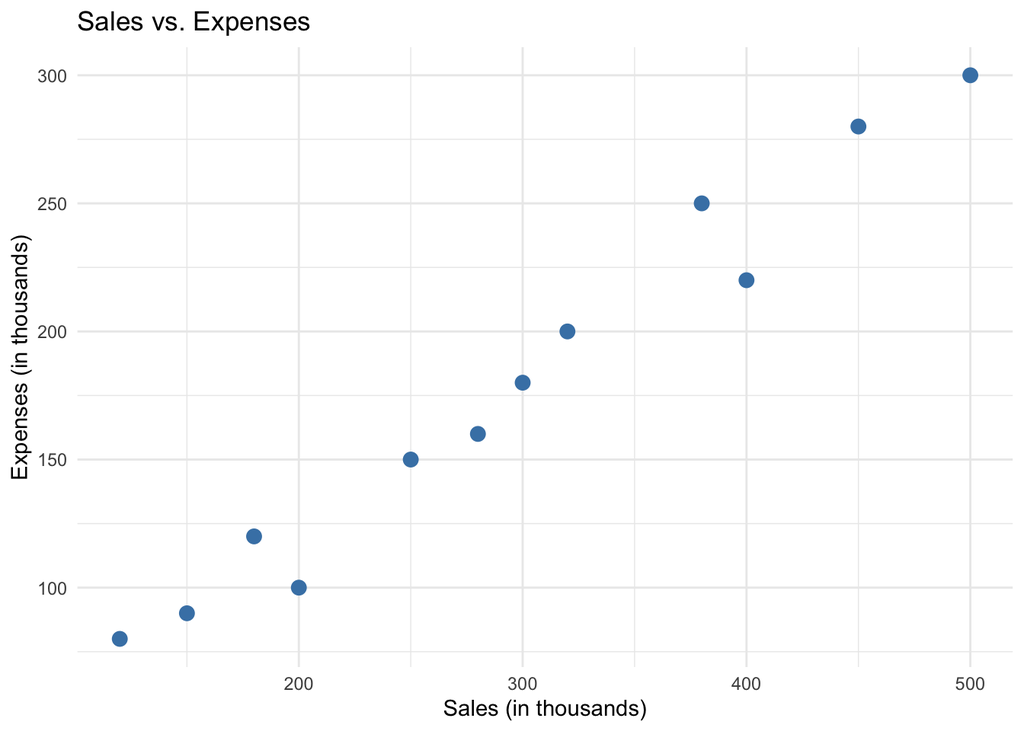

```r
# Custom Scatter Plot Example
customScatterPlot(x = sales_data$sales, y = sales_data$expenses) +
  labs(title = "Sales vs. Expenses", x = "Sales (in thousands)", y = "Expenses (in thousands)")
```

## Custom Bar Plot

The `customBarPlot` function generates a bar plot to visualize the distribution of a numeric variable across different categories.

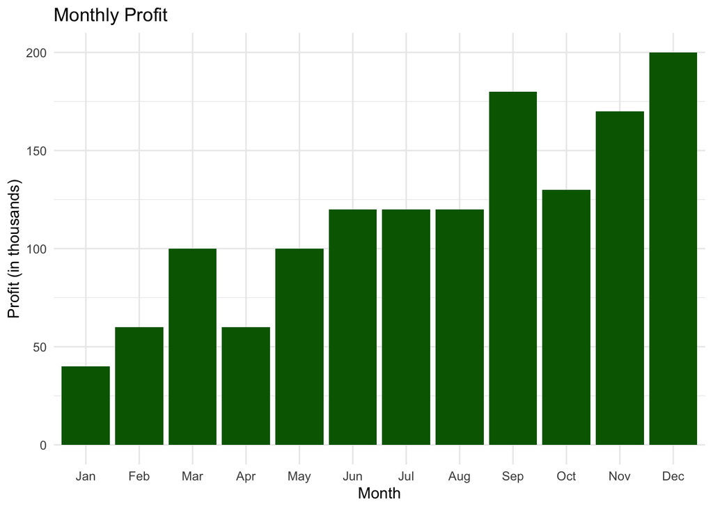

```r
# Custom Bar Plot Example
customBarPlot(x = sales_data$month, y = sales_data$profit) +
  labs(title = "Monthly Profit", x = "Month", y = "Profit (in thousands)")
```

## Custom Line Plot

The `customLinePlot` function produces a line plot suitable for visualizing trends or patterns in a numeric variable over a continuous range.

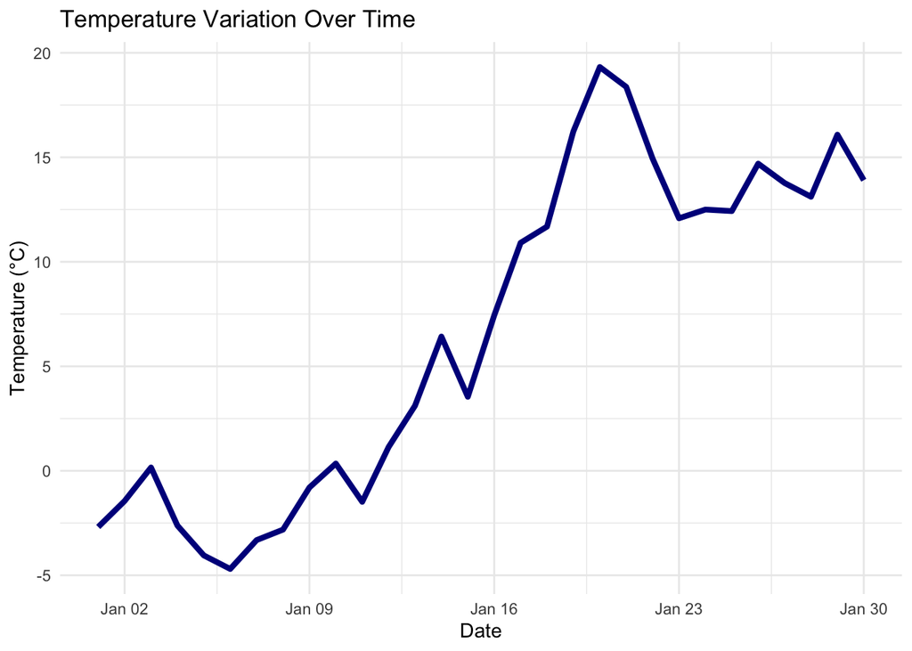

```r
# Custom Line Plot Example with Temperature Data
customLinePlot(x = temperature_data$date, y = temperature_data$temperature, color = "darkblue", size = 1.5) +
  labs(title = "Temperature Variation Over Time", x = "Date", y = "Temperature (°C)")
```

## Shiny Gadgets

```r
# Scatter Plot Gadget
scatterPlotGadget(data)
```

[output not shown]

Shiny applications not supported in static R Markdown documents

```r
# Bar Plot Gadget
barPlotGadget(data_bar)
```

Shiny applications not supported in static R Markdown documents

```r
# Line Plot Gadget
linePlotGadget(data_line)
```

Shiny applications not supported in static R Markdown documents

## Future Work

While the current version of the package provides essential functionality, there are opportunities for future improvements:

1. **Additional Plot Types:** Expand the package to support more plot types, such as histograms or boxplots.
2. **Interactive Gadgets:** Enhance Shiny gadgets to provide users with more interactive features for real-time exploration.
3. **Customization Options:** Introduce additional customization options for users to control various plot parameters easily.

Feel free to contribute, provide feedback, or suggest new features for the continuous improvement of this package!